[figure not shown]

## **🛒💼Ingreso laboral y Capital Humano🎓**

### Modelos inferenciales mediante regresión lineal (OLS)

## Análisis inferencial

### El efecto de los **años de escolaridad en los ingresos personales**

Desde el punto de vista de la teoría del **capital humano**, la educación (medida en años de estudio o nivel escolar alcanzado); la experiencia laboral (número de años laborando y su versión cuadrática), junto con la capacitación y la salud y la nutrición son elementos claves en el desarollo del capitla humano. Algunos de estos elementos aparecen integrados en la **Ecuación de Mincer**, ésta se basa en un modelo semilogarítmico que se utiliza para estimar el retorno de la educación en los ingresos laborales.

La ecuación de Mincer en su versión básica es la siguiente:

$$\hat{log_{im}} = \hat{\beta}_0 +
\hat{\beta}_1 aniosestudio+ \hat{\beta}_2 aniosexperiencia+
\hat{\beta}_3 aniosexperiencia^2+ \hat{\varepsilon}$$

El cálculo se realiza considerando el logaritmo de los ingresos mensuales (log_im) como variable dependiente y los años de educación(aniosestudio), la experiencia laboral(aniosexperiencia) y la experiencia laboral al cuadrado(aniosexperiencia^2) para capturar los efectos de no lineales, como variables independientes.  
Esta función permite identificar el incremento en los ingresos laborales como resultado de los años de escolaridad.  
Considerando que los años de escolaridad y la experiencia no son las únicas variable que inciden en el monto del ingreso personal, para mejorar la predicción del modelo se recomienda integrar variables como: el sexo o geográficas como: la región y la población (rural, urbano) entre otras variables.

```
##
## Resultados de los Modelos de la ecuación de Mincer
## ============================================================================================
##                                               Dependent variable:
##                     ------------------------------------------------------------------------
##                                                      log_im
##                             Modelo 1                Modelo 2                Modelo 3
##                               (1)                      (2)                     (3)
## --------------------------------------------------------------------------------------------
## anios_estudio               0.108***                0.117***                0.117***
##                             (0.009)                  (0.011)                 (0.011)
##
## anios_experiencia                                     0.004                   0.009
##                                                      (0.003)                 (0.009)
##
## anios_experiencia_2                                                          -0.0001
##                                                                             (0.0001)
##
## Constant                    6.733***                6.542***                6.495***
##                             (0.087)                  (0.155)                 (0.179)
##
## --------------------------------------------------------------------------------------------
## Observations                  993                      993                     993
## R2                           0.123                    0.125                   0.125
## Adjusted R2                  0.122                    0.123                   0.122
## Residual Std. Error     0.986 (df = 991)        0.985 (df = 990)        0.986 (df = 989)
## F Statistic         138.824*** (df = 1; 991) 70.620*** (df = 2; 990) 47.139*** (df = 3; 989)
## ============================================================================================
## Note:                                                            *p<0.1; **p<0.05; ***p<0.01
```

### Modelo 1.

Se realiza sólo para evaluar como se comporta el modelo ante la presencia de la variable años de escolaridad. Se observa que la variable es significativa y positiva.

### Modelo 3.

📉 En términos económicos, esto refleja una desaceleración en el retorno de la experiencia: el ingreso crece al principio, pero a ritmos cada vez menores, e incluso puede disminuir en etapas avanzadas de la vida laboral.

📊 Este hallazgo es consistente con el análisis descriptivo previo, donde se utilizó la variable edad (derivada de escolaridad + experiencia + 6 años) y se observó que el ingreso personal tiende a estabilizarse o disminuir en edades mayores.

```
##
## Resultados de los Modelos de la ecuación de Mincer
## ===========================================================================================
##                                               Dependent variable:
##                     -----------------------------------------------------------------------
##                                                     log_im
##                            Modelo 4                Modelo 5                Modelo 6
##                               (1)                     (2)                     (3)
## -------------------------------------------------------------------------------------------
## anios_estudio              0.118***                0.118***                0.117***
##                             (0.011)                 (0.011)                 (0.011)
##
## anios_experiencia            0.007                   0.007                   0.007
##                             (0.009)                 (0.009)                 (0.009)
##
## anios_experiencia_2         -0.0001                 -0.0001                 -0.0001
##                            (0.0001)                (0.0001)                (0.0001)
##
## Mujer                      -0.220***
##                             (0.063)
##
## Hombre                                             0.220***                0.227***
##                                                     (0.063)                 (0.063)
##
## municipio                                                                    0.003
##                                                                             (0.002)
##
## Constant                   6.622***                6.402***                6.337***
##                             (0.181)                 (0.180)                 (0.189)
##
## -------------------------------------------------------------------------------------------
## Observations                  993                     993                     993
## R2                           0.136                   0.136                   0.137
## Adjusted R2                  0.132                   0.132                   0.133
## Residual Std. Error    0.980 (df = 988)        0.980 (df = 988)        0.980 (df = 987)
## F Statistic         38.856*** (df = 4; 988) 38.856*** (df = 4; 988) 31.347*** (df = 5; 987)
## ===========================================================================================
## Note:                                                           *p<0.1; **p<0.05; ***p<0.01
```

### Modelos 4 y 5.

En estos modelos se incorpora, por separado, la variable sexo mediante dos variables dummy:

Mujer = 1 si la persona se identifica como mujer, 0 en otro caso

Hombre = 1 si la persona se identifica como hombre, 0 en otro caso

Ambas variables resultan significativas y con signos opuestos, lo que permite interpretar una brecha salarial por sexo:

Esta diferencia refleja una asimetría estructural en el mercado laboral, donde el sexo de la persona influye significativamente en el nivel de ingreso, incluso controlando por escolaridad y experiencia.

💡 Nota técnica: Aunque ambas variables se incluyen por separado en modelos distintos, el resultado es simétrico y consistente. En modelos con múltiples categorías mutuamente excluyentes, se recomienda incluir una sola dummy y dejar otra como categoría base para evitar problemas de colinealidad perfecta.

[figure not shown]

Brecha salarial por sexo según modelos 4 y 5

```
##
## Resultados de los Modelos de la ecuación de Mincer
## ===================================================================================
##                                                  Dependent variable:
##                                    ------------------------------------------------
##                                                         log_im
##                                           Modelo 7                 Modelo 9
##                                              (1)                     (2)
## -----------------------------------------------------------------------------------
## anios_estudio                             0.114***                 0.055***
##                                            (0.011)                 (0.016)
##
## anios_experiencia                           0.007                   0.014
##                                            (0.009)                 (0.009)
##
## anios_experiencia_2                        -0.0001                 -0.0002
##                                           (0.0001)                 (0.0001)
##
## educ_completoLicenciatura Completa                                 0.575***
##                                                                    (0.191)
##
## educ_completoOtros                                                 0.767***
##                                                                    (0.208)
##
## educ_completoPosgrado                                              1.516***
##                                                                    (0.460)
##
## educ_completoPreparatoria Completa                                 0.457***
##                                                                    (0.107)
##
## Hombre                                    0.281***                 0.293***
##                                            (0.063)                 (0.063)
##
## regionCITRICOLA                            0.335**                 0.357**
##                                            (0.145)                 (0.143)
##
## regionMETROPOLITANA                       0.448***                 0.487***
##                                            (0.096)                 (0.095)
##
## regionNORTE                               0.510***                 0.538***
##                                            (0.156)                 (0.154)
##
## regionPERIFERICA                           0.280**                 0.333***
##                                            (0.121)                 (0.120)
##
## Constant                                  6.069***                 6.386***
##                                            (0.196)                 (0.204)
##
## -----------------------------------------------------------------------------------
## Observations                                 993                     993
## R2                                          0.157                   0.180
## Adjusted R2                                 0.150                   0.170
## Residual Std. Error                   0.970 (df = 984)         0.958 (df = 980)
## F Statistic                        22.843*** (df = 8; 984) 17.946*** (df = 12; 980)
## ===================================================================================
## Note:                                                   *p<0.1; **p<0.05; ***p<0.01
```

### Modelo 8.

Aquí además de las variables de Región, se añadío la variable Tipo de Ocupación o Empleo, aquí se añadió como categoria base “AYUDANTE DE ALGUN OFICIO”. Se decidió no presentar los resultados debido a que aquí tenemos 20 categorias de empleos.

### Efectos del nivel escolar en el porcentaje del ingreso

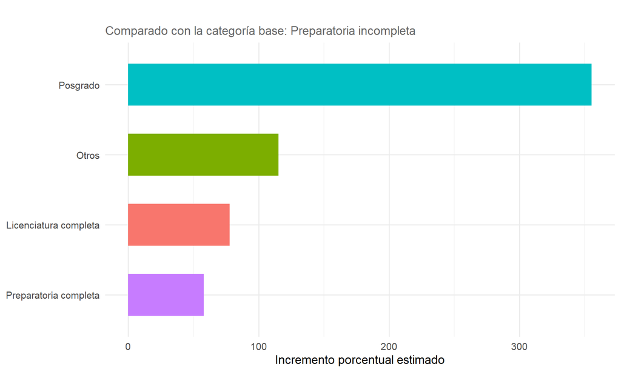

Brecha salarial en la educación modelo 9

🧠 Efecto del Nivel Educativo sobre el Ingreso Laboral El gráfico muestra el incremento porcentual estimado en el ingreso laboral respecto a la categoría base (Preparatoria incompleta), según el Modelo 9:

📚 Otros estudios: +114.3%

🎓 Licenciatura completa: +77.7%

🎓 Preparatoria completa: +58.0%

A partir del **principio de parsimonia** podemos quedarnos con el **Modelo 3** en el se incorpora el efecto no lineal de los años de experiencia al cuadrado, lo que permite explicar los ingresos bajos al principio y al final de la etapa laboral de las personas, y con F mejor que los modelos con más variables

### Observaciones a los modelos

- 💡 Sin embargo, en **estudios económico-sociales**, donde los ingresos dependen de múltiples factores no observables, estos niveles de **R²** son considerados aceptables. En este caso, el modelo se enfoca en estimar el efecto de los años de escolaridad y experiencia laboral, variables que sí muestran una relación significativa con el ingreso.
- ⚠️ Es importante no interpretar el **R²** como una medida de calidad absoluta del modelo, sino como una herramienta para evaluar su capacidad explicativa dentro del marco teórico y los datos disponibles.

4.📌 Se observa que en todos los modelos el **estadístico F** presenta valores significativos (*) y grandes lo que permite considerar que las variables incorporadas ayudan a explicar la variabilidad del ingreso.  
5. 📝En el Modelo 9 al introducir el nivel de Escolaridad Concluido el estadístico F** baja respecto de los modelos anteriores, si bien se obtine una mejora en la R^2ajustada lo hace a costa de complejizar el modelo con muy pocas ganacias respecto de variabilidad para explicar el ingreso mensual.

📌📌📌📌📌📌📌📌📌📌📌📌📌📌📌📌📌📌📌📌📌📌📌📌📌📌📌📌📌📌📌📌📌📌

### Algunas conclusiones derivadas de los resultados de los Modelos: mejores decisiones a partir de la evidencia

- A. Al identificarse una brecha salarial a favor del ingreso de los hombres, se justifica promover para las **mujeres**:
  - 📢promover para las **mujeres**el acceso a apoyos monetarios adicionales que compensen la diferencia,
  - 📢el desarrollo de acciones de capacitación para incentivar el autoempleo y el emprendurismo,
  - 📢acceso a creditos financieros con el fin de mejorar sus ingresos personales.
- B. En general **los ingresos laborales de esta población debe mejorar ya que en promedio están por debajo del salario mínimo diario**, cuando se trata de jefes de familia como único sustento del hogar éste es insuficiente para satisfacer sus necesidades básicas lo que los ubica por debajo de la línea de pobreza.
- C. Avanzar los grados de escolaridad es bueno, pero en terminos de ingresos laborales resulta óptimo concluir los niveles escolares ya que esto afecta significativamente los ingresos laborales de las personas. **Se deben promover acciones encaminadas a lograr que la población concluya los niveles escolares truncos**.
- D. A medida que aumenta la edad de las personas, sobre todo **después de los 60 años**, los ingresos laborales disminuyen, por lo que **implementar acciones que aumenten sus ingresos o reduzcan sus gastos (acceso a servicios de salud, medicamentos, aparatos de movilidad, etc.), mejoran su calidad de vida**.

Prueba de normalidad de los residuos

```
##
##  Jarque Bera Test
##
## data:  emincer_ingreso_03$residuals
## X-squared = 4.8606, df = 2, p-value = 0.08801
```

```
## [1] 0.08801178
```

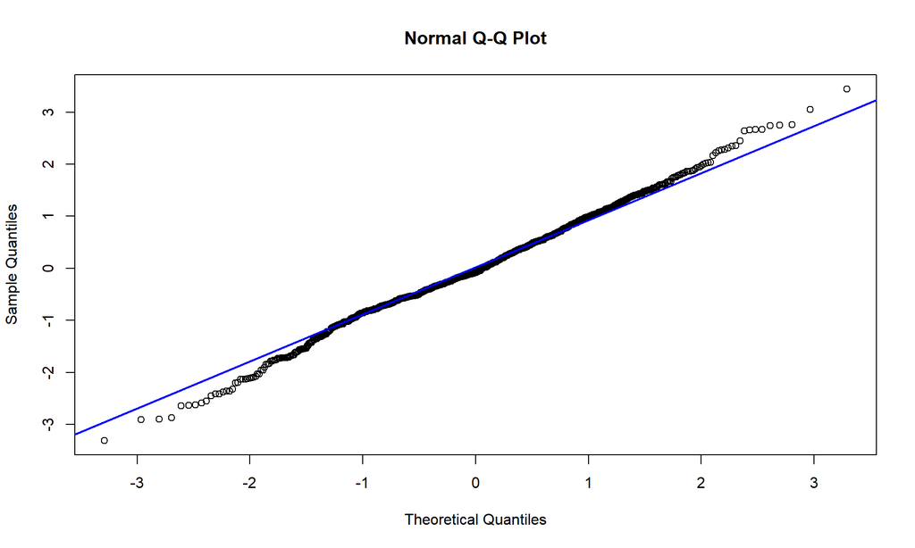

📌 Al aplicar la prueba de Jarque-Bera sobre los residuos del modelo emincer_ingreso_03. El valor p obtenido fue 0.088, por lo que no se rechaza la hipótesis nula de normalidad al nivel de significancia del 5%. Esto sugiere que los residuos no presentan desviaciones significativas respecto a una distribución normal, aunque se recomienda complementar esta evaluación con gráficos Q-Q.  
📌 El gráfico Q-Q muestra que los residuos del modelo se alinean con la normalidad en el rango intercuartílico, pero presentan ligeras desviaciones en las colas. Esto sugiere que, aunque la distribución central es adecuada, podrían existir valores extremos que afecten la simetría o la curtosis.

Vamos a identificar si se cumple el supuesto de varianza constante para todos los valores de las variables independientes

```
##
##  RESET test
##
## data:  emincer_ingreso_03
## RESET = 10.798, df1 = 2, df2 = 987, p-value = 2.296e-05
```

```
##
##  studentized Breusch-Pagan test
##
## data:  emincer_ingreso_03
## BP = 16.882, df = 3, p-value = 0.0007473
```

```
##
## t test of coefficients:
##
##                             Estimate  Std. Error t value Pr(>|t|)
## (Intercept)               6.4946e+00  1.7634e-01 36.8302   <2e-16 ***
## datos_educ$anios_estudio  1.1672e-01  1.1294e-02 10.3345   <2e-16 ***
## anios_experiencia         8.6000e-03  9.1751e-03  0.9373   0.3488
## anios_experiencia_2      -7.7818e-05  1.5753e-04 -0.4940   0.6214
## ---
## Signif. codes:  0 '***' 0.001 '**' 0.01 '*' 0.05 '.' 0.1 ' ' 1
```

Esto indica que se rechaza la hipótesis nula (H₀) de homocedasticidad.

Identificamos si existe multicolinealidad

```
## datos_educ$anios_estudio        anios_experiencia      anios_experiencia_2
##                 1.480046                16.599966                16.537333
```

⚠️ Aunque los valores de GVIF para anios_experiencia y anios_experiencia_2 son elevados, esto se debe a su relación funcional (una es el cuadrado de la otra). Esta colinealidad es esperada y necesaria para capturar efectos no lineales en el ingreso laboral, por lo que no representa un problema metodológico en este contexto.

### La ecuación del Modelo 3

indica una función cuadrática con signo negativo. Su representación nos da idea de como se comporta el ingreso laboral a medida que se incrementa la edad, representación que es consistente con el analisis descritivo observado en la sección anterior.

[figure not shown]

## Modelo robusto para abordar la vulneración de los supuestos clásicos en regresión lineal

## Volver a la página principal